# Final_Tutorial

Prediction of game outcomes in League of Legends by Yong Li, William Ju,

## Introduction

League of Legends is a game that is played by over 180 million players worldwide. It is undoubtly one of the most popular video games, with 120 monthly active users. League of Legends or LOL is a game played by 10 players in a single match that can range from 15-40 minutes on average. Each team (blue and red) consists of 5 players, each with a varying role. The objective of the game is to detroy the enemy's Nexus.

Because LOL is such a popular game, the competitive scene has also seen a dramatic rise, with the 2021 Worlds Tournaments seeing peak 74 million concurrent viewers. Many players want to know what will give them a competitive edge in the game, and through this tutorial, we can get a deeper look into what factors contribute to the winning of games, and try to predict game outcomes.

(Sources: https://activeplayer.io/league-of-legends/ https://www.sportsbusinessjournal.com/Esports/Sections/Media/2021/11/Worlds-2021-Finals-AMA.aspx#:~:text=The%20finals%20between%20DWG%20KIA,60.33%25%20increase%20over%202020%2C%20according)

## Gathering the data:

There are many datasets for LOL available, you can even pull directly from RIOT GAME's official API to gather the data you want. However, the official API has a limit of 100 calls per 2 minutes for normal users. For this reason, we will download a dataset from Kaggles(https://www.kaggle.com/bobbyscience/league-of-legends-diamond-ranked-games-10-min). This dataset contains approximately 10k games played by Diamond Ranked Players.

```python
import pandas as pd
import numpy as np
import matplotlib.pyplot as plt
import seaborn as sns

pd.set_option('display.max_columns', 50)

data = pd.read_csv("high_diamond_ranked_10min.csv")
print(data.shape)
data.head()
```

```
(9879, 40)
```

|  | gameId | blueWins | blueWardsPlaced | blueWardsDestroyed | blueFirstBlood | blueKills | blueDeaths | blueAssists | blueEliteMonsters | blueDragons | blueHeralds | blueTowersDestroyed | blueTotalGold | blueAvgLevel | blueTotalExperience | blueTotalMinionsKilled | blueTotalJungleMinionsKilled | blueGoldDiff | blueExperienceDiff | blueCSPerMin | blueGoldPerMin | redWardsPlaced | redWardsDestroyed | redFirstBlood | redKills | redDeaths | redAssists | redEliteMonsters | redDragons | … |
| --- | --- | --- | --- | --- | --- | --- | --- | --- | --- | --- | --- | --- | --- | --- | --- | --- | --- | --- | --- | --- | --- | --- | --- | --- | --- | --- | --- | --- | --- | --- |
| 0 | 4519157822 | 0 | 28 | 2 | 1 | 9 | 6 | 11 | 0 | 0 | 0 | 0 | 17210 | 6.6 | 17039 | 195 | 36 | 643 | -8 | 19.5 | 1721.0 | 15 | 6 | 0 | 6 | 9 | 8 | 0 | 0 | … |
| 1 | 4523371949 | 0 | 12 | 1 | 0 | 5 | 5 | 5 | 0 | 0 | 0 | 0 | 14712 | 6.6 | 16265 | 174 | 43 | -2908 | -1173 | 17.4 | 1471.2 | 12 | 1 | 1 | 5 | 5 | 2 | 2 | 1 | … |
| 2 | 4521474530 | 0 | 15 | 0 | 0 | 7 | 11 | 4 | 1 | 1 | 0 | 0 | 16113 | 6.4 | 16221 | 186 | 46 | -1172 | -1033 | 18.6 | 1611.3 | 15 | 3 | 1 | 11 | 7 | 14 | 0 | 0 | … |
| 3 | 4524384067 | 0 | 43 | 1 | 0 | 4 | 5 | 5 | 1 | 0 | 1 | 0 | 15157 | 7.0 | 17954 | 201 | 55 | -1321 | -7 | 20.1 | 1515.7 | 15 | 2 | 1 | 5 | 4 | 10 | 0 | 0 | … |
| 4 | 4436033771 | 0 | 75 | 4 | 0 | 6 | 6 | 6 | 0 | 0 | 0 | 0 | 16400 | 7.0 | 18543 | 210 | 57 | -1004 | 230 | 21.0 | 1640.0 | 17 | 2 | 1 | 6 | 6 | 7 | 1 | 1 | … |

We have data on 9879 games of high daimond players, with each game having a collection of 40 columns

#### Description of Columns:

- gameId: Unique RIOT ID of the game. Can be used with the Riot Games API.
- blueWins: The target column. 1 if the blue team has won, 0 otherwise.
- blueWardsPlaced: Number of warding totems placed by the blue team on the map
- blueWardsDestroyed: Number of enemy warding totems the blue team has destroyed
- blueFirstBlood: First kill of the game. 1 if the blue team did the first kill(Extra Gold), 0 otherwise
- blueKills: Number of enemies killed by the blue team
- blueDeaths: Number of deaths (blue team)
- blueAssists: Number of kill assists (blue team)
- blueEliteMonsters: Number of elite monsters killed by the blue team (Dragons and Heralds)
- blueDragons: Number of dragons killed by the blue team
- blueHeralds: Number of heralds killed by the blue team
- blueTowersDestroyed: Number of structures destroyed by the blue team
- blueTotalGold: Blue team total gold
- blueAvgLevel: Blue team average champion level
- blueTotalExperience: Blue team total experience
- blueTotalMinionsKilled: Blue team total minions killed (CS)
- blueTotalJungleMinionsKilled: Blue team total jungle monsters killed
- blueGoldDiff: Blue team gold difference compared to the enemy team
- blueExperienceDiff: Blue team experience difference compared to the enemy team
- blueCSPerMin: Blue team CS (TotalMinionsKilled) per minute
- blueGoldPerMin: Blue team gold per minute ...

The rest are the same variables, except for the red team

## Data Preparation

```python
originalData = data.drop(['gameId'], axis=1)


diffData = pd.DataFrame()
diffData['blueWins'] = originalData['blueWins']
diffData['diffdWardsPlaced'] = originalData['blueWardsPlaced'] - originalData['redWardsPlaced']
diffData['diffWardsDestroyed'] = originalData['blueWardsDestroyed'] - originalData['redWardsDestroyed']
diffData['diffFirstBlood'] = originalData['blueFirstBlood'] - originalData['redFirstBlood']
diffData['diffKills'] = originalData['blueKills'] - originalData['redKills']
diffData['diffDeaths'] = originalData['blueDeaths'] - originalData['redDeaths']
diffData['diffAssists'] = originalData['blueAssists'] - originalData['redAssists']
diffData['diffEliteMonsters'] = originalData['blueEliteMonsters'] - originalData['redEliteMonsters']
diffData['diffDragons'] = originalData['blueDragons'] - originalData['redDragons']
diffData['diffHeralds'] = originalData['blueHeralds'] - originalData['redHeralds']
diffData['diffTowersDestroyed'] = originalData['blueTowersDestroyed'] - originalData['redTowersDestroyed']
diffData['diffTotalGold'] = originalData['blueTotalGold'] - originalData['redTotalGold']
diffData['diffTotalExperience'] = originalData['blueTotalExperience'] - originalData['redTotalExperience']
diffData['diffAvgLevel'] = originalData['blueAvgLevel'] - originalData['redAvgLevel']
diffData['diffTotalMinionsKilled'] = originalData['blueTotalMinionsKilled'] - originalData['redTotalMinionsKilled']
diffData['diffTotalJungleMinionsKilled'] = originalData['blueTotalJungleMinionsKilled'] - originalData['redTotalJungleMinionsKilled']
diffData['diffGoldDiff'] = originalData['blueGoldDiff']
diffData['diffExperienceDiff'] = originalData['blueExperienceDiff']
diffData['diffCSPerMin'] = originalData['blueCSPerMin'] - originalData['redCSPerMin']
diffData['diffGoldPerMin'] = originalData['blueGoldPerMin'] - originalData['redGoldPerMin']

diffData
```

|  | blueWins | diffdWardsPlaced | diffWardsDestroyed | diffFirstBlood | diffKills | diffDeaths | diffAssists | diffEliteMonsters | diffDragons | diffHeralds | diffTowersDestroyed | diffTotalGold | diffTotalExperience | diffAvgLevel | diffTotalMinionsKilled | diffTotalJungleMinionsKilled | diffGoldDiff | diffExperienceDiff | diffCSPerMin | diffGoldPerMin |
| --- | --- | --- | --- | --- | --- | --- | --- | --- | --- | --- | --- | --- | --- | --- | --- | --- | --- | --- | --- | --- |
| 0 | 0 | 13 | -4 | 1 | 3 | -3 | 3 | 0 | 0 | 0 | 0 | 643 | -8 | -0.2 | -2 | -19 | 643 | -8 | -0.2 | 64.3 |
| 1 | 0 | 0 | 0 | -1 | 0 | 0 | 3 | -2 | -1 | -1 | -1 | -2908 | -1173 | -0.2 | -66 | -9 | -2908 | -1173 | -6.6 | -290.8 |
| 2 | 0 | 0 | -3 | -1 | -4 | 4 | -10 | 1 | 1 | 0 | 0 | -1172 | -1033 | -0.4 | -17 | 18 | -1172 | -1033 | -1.7 | -117.2 |
| 3 | 0 | 28 | -1 | -1 | -1 | 1 | -5 | 1 | 0 | 1 | 0 | -1321 | -7 | 0.0 | -34 | 8 | -1321 | -7 | -3.4 | -132.1 |
| 4 | 0 | 58 | 2 | -1 | 0 | 0 | -1 | -1 | -1 | 0 | 0 | -1004 | 230 | 0.0 | -15 | -10 | -1004 | 230 | -1.5 | -100.4 |
| ... | ... | ... | ... | ... | ... | ... | ... | ... | ... | ... | ... | ... | ... | ... | ... | ... | ... | ... | ... | ... |
| 9874 | 1 | -29 | -1 | 1 | 3 | -3 | -2 | 1 | 1 | 0 | 0 | 2519 | 2469 | 0.4 | -18 | 35 | 2519 | 2469 | -1.8 | 251.9 |
| 9875 | 1 | 42 | -21 | -1 | 2 | -2 | 5 | 1 | 1 | 0 | 0 | 782 | 888 | 0.2 | 27 | -8 | 782 | 888 | 2.7 | 78.2 |
| 9876 | 0 | 9 | 1 | -1 | -1 | 1 | -6 | -1 | -1 | 0 | 0 | -2416 | -1877 | -0.4 | -51 | -15 | -2416 | -1877 | -5.1 | -241.6 |
| 9877 | 0 | -52 | 0 | 1 | -1 | 1 | 2 | 1 | 1 | 0 | 0 | -839 | -1085 | -0.6 | -23 | 8 | -839 | -1085 | -2.3 | -83.9 |
| 9878 | 1 | 9 | -2 | 1 | 0 | 0 | 1 | -1 | -1 | 0 | 0 | 927 | -58 | 0.2 | 6 | -2 | 927 | -58 | 0.6 | 92.7 |

9879 rows × 20 columns

## Data Exploration

Lets go ahead and visualize the data to try and identify any obvious trends or patterns that we cant see by just looking at the raw data. Starting with a simple bar graph.

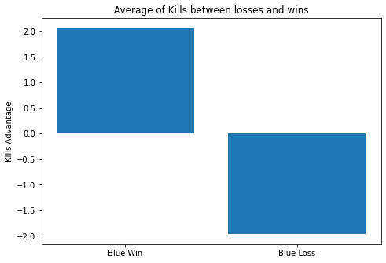

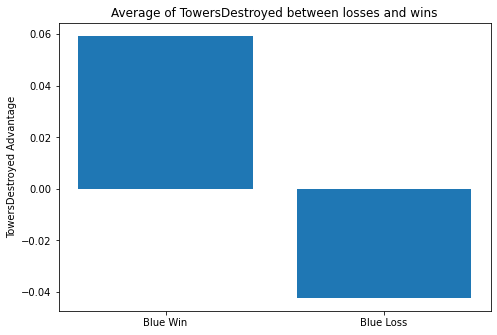

```python
#Functions for loss vs win averaging
def extractParamTeamBased(df:pd.DataFrame, paramName: str):
    blueWinsSample = df[df['blueWins'] == 1]
    blueLossesSample = df[df['blueWins'] == 0]

    xWin = np.average(blueWinsSample[paramName].values)
    xLose = np.average(blueLossesSample[paramName].values)

    fig = plt.figure()
    ax = fig.add_axes([0,0,1,1])
    y = ['Blue Win','Blue Loss']
    x = [xWin, xLose]
    ax.bar(y,x)
    plt.title("Average of " + paramName.replace("diff","") + " between losses and wins")
    plt.ylabel(paramName.replace("diff","") + " Advantage")
    plt.show()

extractParamTeamBased(diffData, "diffKills")
extractParamTeamBased(diffData, "diffTowersDestroyed")
```

We can see from the above that in general, the winning team on average has an advantage in most stats compared to different teams. However, this can be misleading as sometimes they can be a function of winning. Such an example is TowersDestroyed. In order to win, you must destroy the enemy's Nexus meaning that the winning team will always have more towers/structures destroyed. We want to focus in on more prefictive parameters as well as other more correlative variables. Lets look at some other ways to visualize our data.

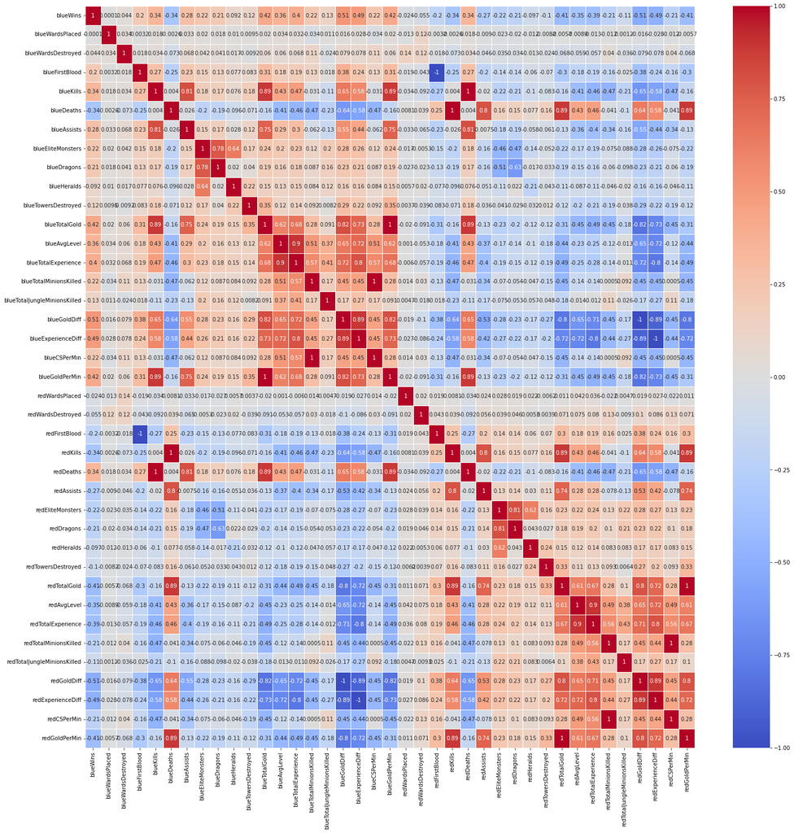

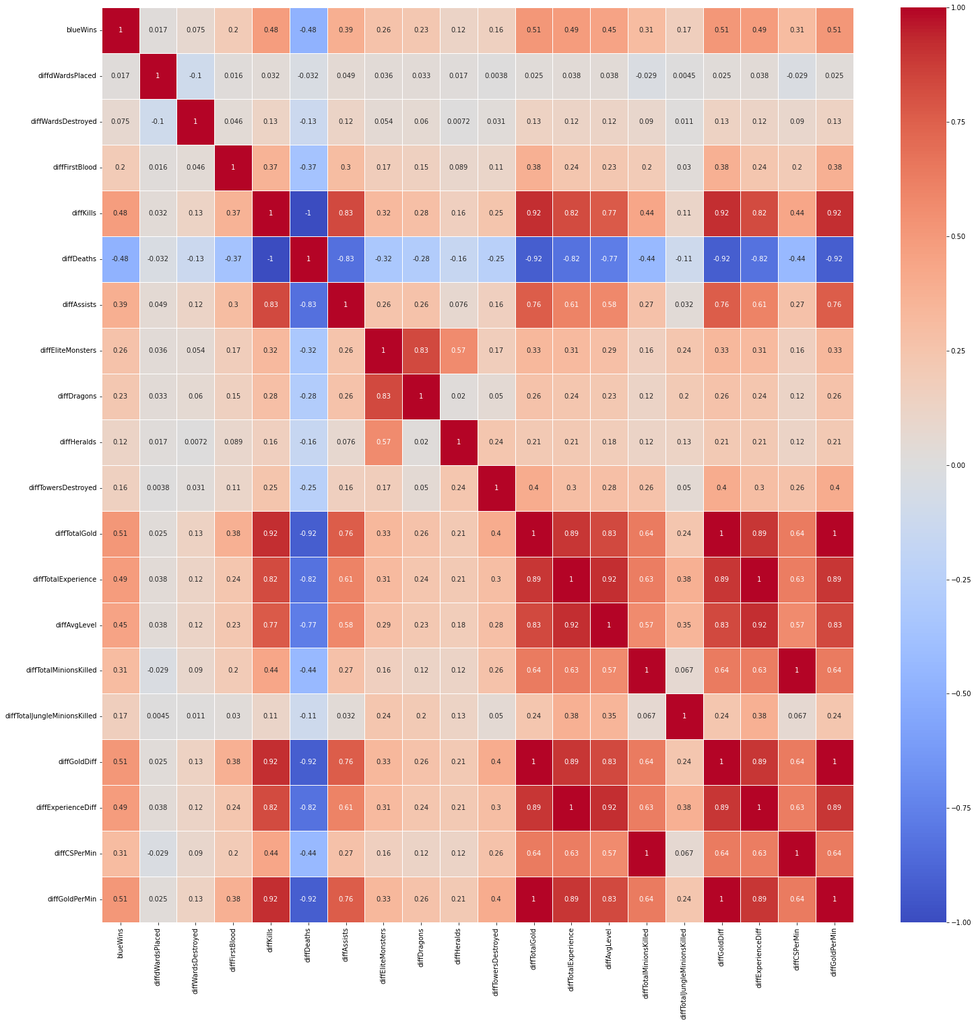

```python
def heatMap(df: pd.DataFrame):
    corr = df.corr().round(4)

    fig, ax = plt.subplots(figsize=(25,25))

    sns.heatmap(corr, annot=True, cmap="coolwarm", ax=ax, linewidths=.5)

heatMap(originalData)
heatMap(diffData)
```

From this heatmap we can see that certain variables/parameters are more correlated to blueWin than others. For example both experience and the gold difference between the two teams has a signifiant coreelation to win. Note that Gold per min and average level are byproducts of total gold and total experience. There are other variables that are highly correlated, which we will also ignore, such as blueDeaths and redKills, as each blueDeath is a result of a red kill.

Something else that I am curious about is the win rate between blue side vs red side. When a player enters the game, they are randomly placed on the blue or red team, so in theory they should be just about 50%. However, the map is not identical for both sides, with each side having small differences in obstacles and the map layout. I want to explore whether these differences account for a signficance in the win rate of being on blue or red team.

```python
winrate = originalData[originalData['blueWins'] == 1].shape[0]/ originalData.shape[0]
print("Blue Side Win rate is: " + str(winrate))
```

```
Blue Side Win rate is: 0.4990383642069035
```

The difference is miniscule, however there is a slight bias for red side. Without a much larger dataset to account for the variance, it would be hard to make any conclusions from this.

## Prediction

```python
from sklearn.neighbors import KNeighborsClassifier
from sklearn.model_selection import train_test_split
from sklearn.metrics import accuracy_score
from sklearn.metrics import classification_report
from sklearn.metrics import confusion_matrix

neigh_og = KNeighborsClassifier(n_neighbors=17)

originalArr = ["blueWardsPlaced","redWardsPlaced","blueWardsDestroyed","redWardsDestroyed","blueFirstBlood","redFirstBlood","blueKills","redKills","blueDeaths","redDeaths","blueAssists","redAssists","blueEliteMonsters","redEliteMonsters","blueDragons","redDragons","blueHeralds","redHeralds","blueTowersDestroyed",
"redTowersDestroyed","blueTotalGold","redTotalGold","blueTotalExperience","redTotalExperience","blueAvgLevel","redAvgLevel","blueTotalMinionsKilled","redTotalMinionsKilled","blueTotalJungleMinionsKilled","redTotalJungleMinionsKilled","blueGoldDiff","blueExperienceDiff","blueCSPerMin",
"redCSPerMin","blueGoldPerMin","redGoldPerMin"]
diffArr = ["diffdWardsPlaced", "diffWardsDestroyed", "diffFirstBlood", "diffKills", "diffDeaths", "diffAssists", "diffEliteMonsters", "diffDragons", "diffHeralds", "diffTowersDestroyed", "diffTotalGold", "diffTotalExperience", "diffAvgLevel", "diffTotalMinionsKilled", "diffTotalJungleMinionsKilled", "diffGoldDiff", "diffExperienceDiff", "diffCSPerMin", "diffGoldPerMin"]

X_og, y_og = originalData.loc[:, originalArr], originalData.loc[:, "blueWins"]

x_og_train, x_og_test, y_og_train, y_og_test = train_test_split(X_og, y_og, random_state=42)

neigh_og.fit(x_og_train, y_og_train)

y_pred = neigh_og.predict(x_og_test)

print(accuracy_score(y_og_test, y_pred))
print(classification_report(y_og_test, y_pred))
print(confusion_matrix(y_og_test, y_pred))

#####################################
neigh_diff = KNeighborsClassifier(n_neighbors=25)

x_diff, y_diff = diffData.loc[:, diffArr], diffData.loc[:, "blueWins"]

x_diff_train, x_diff_test, y_diff_train, y_diff_test = train_test_split(x_diff, y_diff, random_state=42)


neigh_diff.fit(x_diff_train, y_diff_train)

y_pred = neigh_diff.predict(x_diff_test)

print(accuracy_score(y_diff_test, y_pred))
print(classification_report(y_diff_test, y_pred))
print(confusion_matrix(y_diff_test, y_pred))
```

[output not shown]

```
0.5619433198380567
              precision    recall  f1-score   support

           0       0.95      0.13      0.23      1236
           1       0.53      0.99      0.69      1234

    accuracy                           0.56      2470
   macro avg       0.74      0.56      0.46      2470
weighted avg       0.74      0.56      0.46      2470

[[ 162 1074]
 [   8 1226]]
```